# R-Assignment-BCB546-Spring2022-Ceren_Ordas

Ceren Ordas

2022-03-11

1- Create a repository on GitHub named “R_Assignment_BCB546_Spring_2022_Ceren_Ordas and then load it into R Studio.

To do that:

1. Clone the repository.
2. Click File, then New Project, then Version Control, Git on R Studio.
3. Paste the copied repository URL and write the directory name and then create the project.
4. Install the R packages that we need by using `install.packages("package")` and load the ones you don’t have into the library.

```r
library(tidyverse)
```

```r
library(tidyr)
library(dplyr)
library(stringr)
library(ggplot2)
```

- PART I: Data Inspection:
- Open the files `fang_et_al_genotypes` and `snp_position.txt` by going to the BCB546-Spring2022 GitHub repository by using their links and transform these files into a data frame.

```r
fang_et_al_genotypes <- read.table("https://raw.githubusercontent.com/EEOB-BioData/BCB546-Spring2022/main/assignments/UNIX_Assignment/fang_et_al_genotypes.txt", header = TRUE,)
snp_position <- read.table("https://raw.githubusercontent.com/EEOB-BioData/BCB546-Spring2022/main/assignments/UNIX_Assignment/snp_position.txt", header = TRUE, sep = "\t")
```

To inspect these data files, double click on them in the Environment tab.

- Use the codes below to inspect both the data:

`object.size()` - file size.

`nrow()` - number of rows.

`ncol()` - number of columns.

`head()` - first 6 rows.

`tail()` - last 6 rows.

`dim()` - dimensions by row and column.

`str()` - structure which includes the name, type and preview of data in each column.

`colnames()` - column names.

`sapply(dataframe, class)` - class of each column of data.

- For fang_et_al_genotypes:

```r
object.size(fang_et_al_genotypes)
```

[output not shown]

```r
nrow(fang_et_al_genotypes)
```

```
## [1] 2782
```

```r
ncol(fang_et_al_genotypes)
```

[output not shown]

```r
head(fang_et_al_genotypes)
```

```
##   Sample_ID   JG_OTU Group abph1.20 abph1.22 ae1.3 ae1.4 ae1.5 an1.4 ba1.6
## 1     SL-15 T-aust-1 TRIPS      ?/?      ?/?   T/T   G/G   T/T   C/C   ?/?
## 2     SL-16 T-aust-2 TRIPS      ?/?      ?/?   T/T   ?/?   T/T   C/C   A/G
## 3     SL-11 T-brav-1 TRIPS      ?/?      ?/?   T/T   G/G   T/T   ?/?   G/G
## 4     SL-12 T-brav-2 TRIPS      ?/?      ?/?   T/T   G/G   T/T   C/C   G/G
## 5     SL-18   T-cund TRIPS      ?/?      ?/?   T/T   G/G   T/T   C/C   ?/?
## 6      SL-2 T-dact-1 TRIPS      ?/?      ?/?   T/T   G/G   T/T   C/C   A/G
##   ba1.9 bt2.5 bt2.7 bt2.8 Fea2.1 Fea2.5 id1.3 lg2.11 lg2.2 pbf1.1 pbf1.2 pbf1.3
## 1   G/G   ?/?   A/A   ?/?    C/C    A/A   T/T    C/C   A/A    ?/?    ?/?    ?/?
## 2   G/G   ?/?   A/A   ?/?    C/C    A/A   T/T    C/C   A/A    T/T    ?/?    ?/?
## 3   G/G   C/C   A/A   ?/?    ?/?    A/A   T/T    C/C   A/A    T/T    ?/?    ?/?
## 4   G/G   C/C   A/A   ?/?    ?/?    A/A   T/T    C/C   A/A    T/T    ?/?    ?/?
## 5   G/G   ?/?   A/A   ?/?    C/C    A/A   T/T    C/C   A/A    T/T    ?/?    ?/?
## 6   G/G   ?/?   A/A   ?/?    C/C    A/A   T/T    C/C   A/A    T/T    ?/?    ?/?
##   pbf1.5 pbf1.6 pbf1.7 pbf1.8 PZA00003.11 PZA00004.2 PZA00005.8 PZA00005.9
```

[output cut: 1021 more lines]

```r
tail(fang_et_al_genotypes)
```

```
##      Sample_ID             JG_OTU Group abph1.20 abph1.22 ae1.3 ae1.4 ae1.5
## 2777    SYN262 Zmm-IL-W22-Rrstd_v ZMMIL      C/C      A/A   T/T   G/G   C/C
## 2778     S0398      Zmm-IL-W64A_a ZMMIL      G/G      A/A   T/T   G/G   C/C
## 2779     S1636    Zmm-IL-W64A_b_s ZMMIL      G/G      A/A   T/T   G/G   C/C
## 2780    CU0201        Zmm-IL-WD_f ZMMIL      C/C      A/A   T/T   G/G   C/C
## 2781     S0215         Zmm-IL-Wf9 ZMMIL      G/G      A/A   T/T   ?/?   C/C
## 2782    CU0202  Zmm-IL-Yu796_NS_f ZMMIL      C/C      A/A   T/T   G/G   C/C
##      an1.4 ba1.6 ba1.9 bt2.5 bt2.7 bt2.8 Fea2.1 Fea2.5 id1.3 lg2.11 lg2.2
## 2777   C/C   G/G   G/G   C/C   A/A   A/A    C/C    A/A   C/C    C/C   G/G
## 2778   C/C   G/G   G/G   C/C   G/G   A/A    ?/?    A/A   C/C    C/C   A/A
## 2779   C/C   G/G   G/G   C/C   G/G   A/A    G/G    A/A   C/C    C/C   A/A
## 2780   C/C   G/G   G/G   C/C   G/G   A/A    G/G    ?/?   C/C    C/C   G/G
## 2781   C/C   G/G   G/G   C/C   G/G   A/A    G/G    A/A   C/C    C/C   A/A
## 2782   C/C   ?/?   G/G   C/C   G/G   A/A    G/G    ?/?   ?/?    C/C   G/G
##      pbf1.1 pbf1.2 pbf1.3 pbf1.5 pbf1.6 pbf1.7 pbf1.8 PZA00003.11 PZA00004.2
```

[output cut: 1119 more lines]

```r
str(fang_et_al_genotypes)
```

```
## 'data.frame':    2782 obs. of  986 variables:
##  $ Sample_ID     : chr  "SL-15" "SL-16" "SL-11" "SL-12" ...
##  $ JG_OTU        : chr  "T-aust-1" "T-aust-2" "T-brav-1" "T-brav-2" ...
##  $ Group         : chr  "TRIPS" "TRIPS" "TRIPS" "TRIPS" ...
##  $ abph1.20      : chr  "?/?" "?/?" "?/?" "?/?" ...
##  $ abph1.22      : chr  "?/?" "?/?" "?/?" "?/?" ...
##  $ ae1.3         : chr  "T/T" "T/T" "T/T" "T/T" ...
##  $ ae1.4         : chr  "G/G" "?/?" "G/G" "G/G" ...
##  $ ae1.5         : chr  "T/T" "T/T" "T/T" "T/T" ...
##  $ an1.4         : chr  "C/C" "C/C" "?/?" "C/C" ...
##  $ ba1.6         : chr  "?/?" "A/G" "G/G" "G/G" ...
##  $ ba1.9         : chr  "G/G" "G/G" "G/G" "G/G" ...
##  $ bt2.5         : chr  "?/?" "?/?" "C/C" "C/C" ...
##  $ bt2.7         : chr  "A/A" "A/A" "A/A" "A/A" ...
##  $ bt2.8         : chr  "?/?" "?/?" "?/?" "?/?" ...
```

[output cut: 86 more lines]

```r
colnames(fang_et_al_genotypes)
```

```
##   [1] "Sample_ID"      "JG_OTU"         "Group"          "abph1.20"
##   [5] "abph1.22"       "ae1.3"          "ae1.4"          "ae1.5"
##   [9] "an1.4"          "ba1.6"          "ba1.9"          "bt2.5"
##  [13] "bt2.7"          "bt2.8"          "Fea2.1"         "Fea2.5"
##  [17] "id1.3"          "lg2.11"         "lg2.2"          "pbf1.1"
##  [21] "pbf1.2"         "pbf1.3"         "pbf1.5"         "pbf1.6"
##  [25] "pbf1.7"         "pbf1.8"         "PZA00003.11"    "PZA00004.2"
##  [29] "PZA00005.8"     "PZA00005.9"     "PZA00006.13"    "PZA00006.14"
##  [33] "PZA00008.1"     "PZA00010.5"     "PZA00013.10"    "PZA00013.11"
##  [37] "PZA00013.9"     "PZA00015.4"     "PZA00017.1"     "PZA00018.5"
##  [41] "PZA00029.11"    "PZA00029.12"    "PZA00030.11"    "PZA00031.5"
##  [45] "PZA00041.3"     "PZA00042.2"     "PZA00042.5"     "PZA00043.7"
##  [49] "PZA00045.1"     "PZA00047.2"     "PZA00049.12"    "PZA00050.9"
##  [53] "PZA00051.2"     "PZA00058.5"     "PZA00058.6"     "PZA00060.2"
##  [57] "PZA00061.1"     "PZA00065.2"     "PZA00069.4"     "PZA00070.5"
```

[output cut: 232 more lines]

```r
dim(fang_et_al_genotypes)
```

```
## [1] 2782  986
```

```r
sapply(fang_et_al_genotypes, class)
```

[output not shown]

[output cut: 341 more lines]

[output not shown]

For snp_position:

```r
object.size(snp_position)
```

```
## 327392 bytes
```

```r
nrow(snp_position)
```

```
## [1] 983
```

```r
ncol(snp_position)
```

```
## [1] 15
```

```r
head(snp_position)
```

```
##     SNP_ID cdv_marker_id Chromosome  Position alt_pos mult_positions amplicon
## 1 abph1.20          5976          2  27403404                           abph1
## 2 abph1.22          5978          2  27403892                           abph1
## 3    ae1.3          6605          5 167889790                             ae1
## 4    ae1.4          6606          5 167889682                             ae1
## 5    ae1.5          6607          5 167889821                             ae1
## 6    an1.4          5982          1 240498509                             an1
##   cdv_map_feature.name  gene candidate.random Genaissance_daa_id
## 1             AB042260 abph1        candidate               8393
## 2             AB042260 abph1        candidate               8394
## 3                  ae1   ae1        candidate               8395
## 4                  ae1   ae1        candidate               8396
## 5                  ae1   ae1        candidate               8397
## 6                  an1   an1        candidate               8398
##   Sequenom_daa_id count_amplicons count_cmf count_gene
## 1           10474               1         1          1
## 2           10475               0         0          0
## 3           10477               1         1          1
## 4           10478               0         0          0
## 5           10479               0         0          0
## 6           10481               1         1          1
```

```r
tail(snp_position)
```

```
##     SNP_ID cdv_marker_id Chromosome  Position alt_pos mult_positions amplicon
## 978 zap1.2          3514          2 233128584                            zap1
## 979 zen1.1          3519    unknown   unknown                            zen1
## 980 zen1.2          3520    unknown   unknown                            zen1
## 981 zen1.4          3521    unknown   unknown                            zen1
## 982 zfl2.6          6463          2  12543294                            zfl2
## 983 zmm3.4          3527          9  16966348                            zmm3
##     cdv_map_feature.name gene candidate.random Genaissance_daa_id
## 978               L46400 zap1        candidate               8434
## 979             CF649098 zen1        candidate               8435
## 980             CF649098 zen1        candidate               8436
## 981             CF649098 zen1        candidate               8437
## 982                 zfl2 zfl2        candidate               8438
## 983               Y09301 zmm3        candidate              10104
##     Sequenom_daa_id count_amplicons count_cmf count_gene
## 978           11823               1         0          1
## 979           11824               1         1          1
## 980           11826               0         0          0
## 981           11827               0         0          0
## 982           11828               1         1          1
## 983           11829               1         0          1
```

```r
dim(snp_position)
```

```
## [1] 983  15
```

```r
str(snp_position)
```

```
## 'data.frame':    983 obs. of  15 variables:
##  $ SNP_ID              : chr  "abph1.20" "abph1.22" "ae1.3" "ae1.4" ...
##  $ cdv_marker_id       : int  5976 5978 6605 6606 6607 5982 3463 3466 5983 5985 ...
##  $ Chromosome          : chr  "2" "2" "5" "5" ...
##  $ Position            : chr  "27403404" "27403892" "167889790" "167889682" ...
##  $ alt_pos             : chr  "" "" "" "" ...
##  $ mult_positions      : chr  "" "" "" "" ...
##  $ amplicon            : chr  "abph1" "abph1" "ae1" "ae1" ...
##  $ cdv_map_feature.name: chr  "AB042260" "AB042260" "ae1" "ae1" ...
##  $ gene                : chr  "abph1" "abph1" "ae1" "ae1" ...
##  $ candidate.random    : chr  "candidate" "candidate" "candidate" "candidate" ...
##  $ Genaissance_daa_id  : int  8393 8394 8395 8396 8397 8398 8399 8400 8401 8402 ...
##  $ Sequenom_daa_id     : int  10474 10475 10477 10478 10479 10481 10482 10483 10486 10487 ...
##  $ count_amplicons     : int  1 0 1 0 0 1 1 0 1 0 ...
##  $ count_cmf           : int  1 0 1 0 0 1 0 0 1 0 ...
##  $ count_gene          : int  1 0 1 0 0 1 1 0 1 0 ...
```

```r
colnames(snp_position)
```

```
##  [1] "SNP_ID"               "cdv_marker_id"        "Chromosome"
##  [4] "Position"             "alt_pos"              "mult_positions"
##  [7] "amplicon"             "cdv_map_feature.name" "gene"
## [10] "candidate.random"     "Genaissance_daa_id"   "Sequenom_daa_id"
## [13] "count_amplicons"      "count_cmf"            "count_gene"
```

```r
sapply(snp_position, class)
```

```
##               SNP_ID        cdv_marker_id           Chromosome
##          "character"            "integer"          "character"
##             Position              alt_pos       mult_positions
##          "character"          "character"          "character"
##             amplicon cdv_map_feature.name                 gene
##          "character"          "character"          "character"
##     candidate.random   Genaissance_daa_id      Sequenom_daa_id
##          "character"            "integer"            "integer"
##      count_amplicons            count_cmf           count_gene
##            "integer"            "integer"            "integer"
```

- We need to create two new data frames which are sorted by the species’ ID’s for both the species from the fang_et_al_genotypes file:

```r
Maize_ID_Data <- fang_et_al_genotypes[which(fang_et_al_genotypes$Group == "ZMMIL" | fang_et_al_genotypes$Group == "ZMMLR" | fang_et_al_genotypes$Group == "ZMMMR"),]
Teosinte_ID_Data <- fang_et_al_genotypes[which(fang_et_al_genotypes$Group == "ZMPBA" | fang_et_al_genotypes$Group == "ZMPIL" | fang_et_al_genotypes$Group == "ZMPJA"),]
```

- After that, we need to get the columns 1,3 and 4 from the snp_position file to combine them into just one.
- To do that:

```r
SNP_Chromosome_Positions <- snp_position[,c(1,3,4)]
```

- After that, we need to combine our data files in order to organize it so the first column says “SNP_ID”, second column says “Chromosome” and the third column says “Position” and then followed by the genotype data.
- To do that we need to transpose the ‘Maize_ID_Data’ and the ‘Teosinte_ID_Data’ and then combine them.

```r
Transposed_Maize_ID_Data <- as.data.frame(t(Maize_ID_Data[,-1]))
colnames(Transposed_Maize_ID_Data) <- Maize_ID_Data$Sample_ID
Transposed_Teosinte_ID_Data <- as.data.frame(t(Teosinte_ID_Data[,-1]))
colnames(Transposed_Teosinte_ID_Data) <- Teosinte_ID_Data$Sample_ID
```

```r
Transposed_Maize_ID_Data <- cbind(SNP_ID = row.names(Transposed_Maize_ID_Data), Transposed_Maize_ID_Data)
Transposed_Teosinte_ID_Data <- cbind(SNP_ID = row.names(Transposed_Teosinte_ID_Data), Transposed_Teosinte_ID_Data)
```

- In order to combine the transposed data frames that we have with the first file SNP_Chromosome_Positions’, we should merge the files by the SNP_ID. We need to combine the transposed data frames with the file ‘SNP_Chromosome_Positions’ which is followed by maize or teosinte.
- To do that:

```r
Maize_Chromosomes <- merge(SNP_Chromosome_Positions,Transposed_Maize_ID_Data, by = "SNP_ID")
Teosinte_Chromosomes <- merge(SNP_Chromosome_Positions,Transposed_Teosinte_ID_Data, by = "SNP_ID")
```

```r
Maize_Chromosomes[Maize_Chromosomes=="NA"] <- "?/?"
Teosinte_Chromosomes[Teosinte_Chromosomes=="NA"] <- "?/?"
```

- After that, we sort the new files that we got by position by using the ‘order()’ function.

```r
Maize_Chrom_Ascending <- Maize_Chromosomes[order(suppressWarnings(as.numeric(Maize_Chromosomes$Position))), ]
Maize_Chrom_Descending <- Maize_Chromosomes[order(suppressWarnings(as.numeric(Maize_Chromosomes$Position, decreasing = T))), ]
Teosinte_Chrom_Ascending <- Teosinte_Chromosomes[order(suppressWarnings(as.numeric(Teosinte_Chromosomes$Position))), ]
Teosinte_Chrom_Descending <- Teosinte_Chromosomes[order(suppressWarnings(as.numeric(Teosinte_Chromosomes$Position, decreasing = T))), ]
```

- Use library to run tidyverse to use the ‘%>%’ function even though I ran it before but for some reason if I do not run it again, it did not work. :/

```r
library(tidyverse)
```

```r
Filter_By_Chromosome <- function(x, df){
  df %>%
    filter(Position !="unknown" || Position != "multiple") %>%
    filter(Chromosome != "multiple" || Chromosome != "unknown") %>%
    filter(Chromosome == x)}

Maize_Ascending_ByChromosome <- lapply(sort(unique(Maize_Chrom_Ascending$Chromosome)), Filter_By_Chromosome, Maize_Chrom_Ascending)
invisible(lapply(Maize_Ascending_ByChromosome, function(x) write.csv(x, file = paste0("Maize_Ascending_Chrom", x$Chromosome[1], ".txt"))))
```

```r
Maize_Descending_ByChromosome_dash <- data.frame(lapply(Maize_Chrom_Descending, gsub, pattern = "[?]", replacement = "-"))
Maize_Descending_ByChromosome <- lapply(sort(unique(Maize_Descending_ByChromosome_dash$Chromosome)), Filter_By_Chromosome, Maize_Descending_ByChromosome_dash)
invisible(lapply(Maize_Descending_ByChromosome, function(x) write.csv(x, file = paste0("Maize_Descending_Chrom", x$Chromosome[1], ".txt"))))
```

```r
Teosinte_Ascending_ByChromosome <- lapply(sort(unique(Teosinte_Chrom_Ascending$Chromosome)), Filter_By_Chromosome, Teosinte_Chrom_Ascending)
invisible(lapply(Teosinte_Ascending_ByChromosome,function(x) write.csv(x, file = paste0("Teosinte_Ascending_Chrom", x$Chromosome[1], ".txt"))))
```

```r
Teosinte_Descending_ByChromosome_dash <- data.frame(lapply(Teosinte_Chrom_Descending, gsub, pattern = "[?]", replacement = "-"))
Teosinte_Descending_ByChromosome <- lapply(sort(unique(Teosinte_Descending_ByChromosome_dash$Chromosome)), Filter_By_Chromosome, Teosinte_Descending_ByChromosome_dash)
invisible(lapply(Teosinte_Descending_ByChromosome,function(x) write.csv(x, file = paste0("Teosinte_Descending_Chrom", x$Chromosome[1], ".txt"))))
```

- PART II: Visualization:

In Part II, we will use ggplot to investigate (by visualization) to look at SNPs per chromosome, missing data and the amount of heterozygosity and then our own visualization.

- ggplot:

We need to transform the data in order to make the position and chromosome numeric.

To do that:

```r
Maize_Numeric_Chrom <- transform(Maize_Chromosomes, Chromosome =as.numeric(Chromosome), Position=as.numeric(Position))
Teosinte_Numeric_Chrom <- transform(Teosinte_Chromosomes, Chromosome =as.numeric(Chromosome), Position=as.numeric(Position))
```

- Now, by using the ‘pivot_longer()’ function to tidy up the data and merging the pivoted data with the SNP position data to make our table numeric by chromosome, we will be able to plot the number of SNPs on each chromosome from the ‘fang_et_al_genotypes’.

```r
fang_et_al_pivot <- fang_et_al_genotypes %>% pivot_longer(!c(Sample_ID, JG_OTU, Group), names_to="SNP_ID", values_to= "NT")
merged_fang_et_al_pivot <- merge(fang_et_al_pivot, snp_position, by="SNP_ID")
merged_fang_et_al_pivot_numeric <- merged_fang_et_al_pivot[!is.na(as.numeric(merged_fang_et_al_pivot$Chromosome)),]
```

- Now we will look at the total number of SNPs per chromosome for our Maize and Teosinte data and drop the NA’s for our missing and multiple values: To do that:

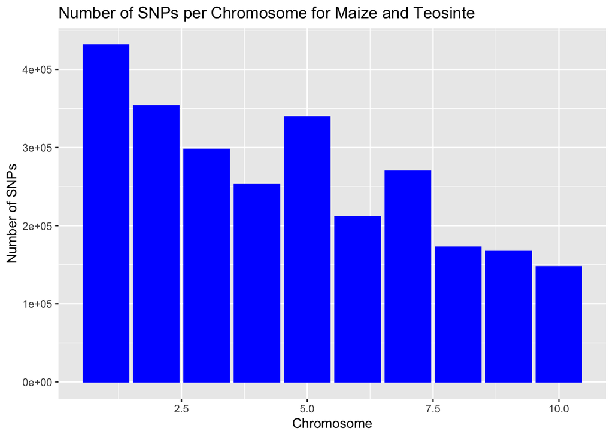

```r
merged_fang_et_al_pivot_numeric %>%
     select(SNP_ID, Chromosome, Position) %>%
     drop_na() %>%
     ggplot()+
     geom_bar(mapping = aes(as.numeric(Chromosome)), color="blue", fill="blue")+ ggtitle("Number of SNPs per Chromosome for Maize and Teosinte") + labs(x = "Chromosome", y = "Number of SNPs")
```

- Now, we will be plotting the distribution of SNPs across chromosomes.

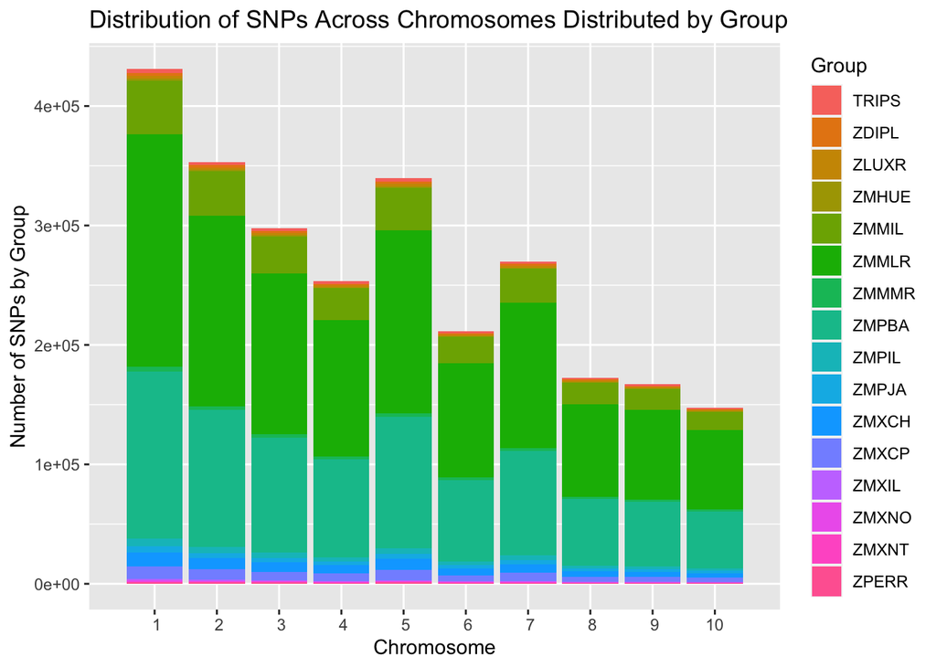

```r
ggplot(data = merged_fang_et_al_pivot_numeric) + geom_bar(mapping = aes(as.numeric(Chromosome), fill=Group)) + scale_x_discrete(limit=c(1:10)) + labs(x = "Chromosome", y="Number of SNPs by Group") + ggtitle("Distribution of SNPs Across Chromosomes Distributed by Group")
```

- Now we will be looking at amount of heterozygosity and the missing data. To do that, we will be adding a new column named ‘Heterozygosity’ to our ‘merged_fang_et_al_pivot_numeric’ data frame.

```r
merged_fang_et_al_pivot_numeric$Heterozygosity <- "Heterozygous"
```

- Now we will replace the missing data -> ?/? with ‘Missing Data’ in the column named Heterozygosity.

```r
merged_fang_et_al_pivot_numeric$Heterozygosity[merged_fang_et_al_pivot_numeric$NT == "?/?"] <- "Missing Data"
```

- After that, we will be setting up values in such way that in the Heterozygosity column, the values will be changed to ‘Homozygous’ if they say “A/A”, “T/T”, “C/C”, “G/G”.

```r
merged_fang_et_al_pivot_numeric$Heterozygosity[merged_fang_et_al_pivot_numeric$NT %in% c("A/A", "T/T", "C/C", "G/G")] <- "Homozygous"
```

- Finally, we will now plot our data of the proportion of homozygous vs heterozygous sites, as well as missing data in each sample in each group.

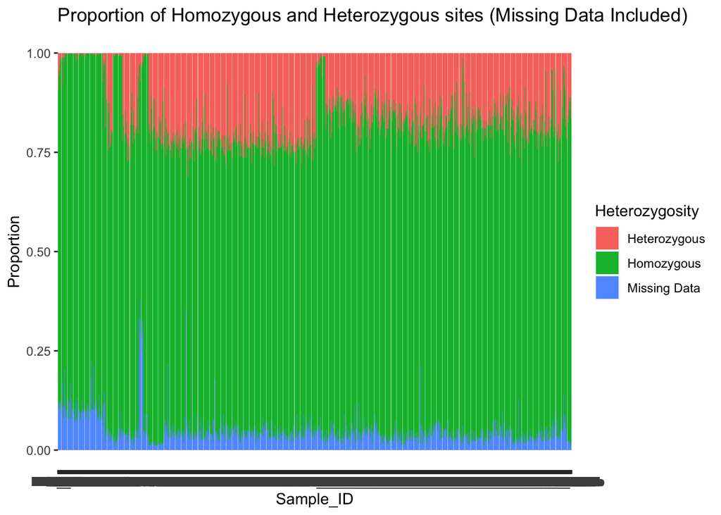

```r
g <- ggplot(data = merged_fang_et_al_pivot_numeric) + geom_bar(mapping = aes(x = Sample_ID, fill = Heterozygosity), position = "fill") + labs(x = "Sample_ID", y="Proportion") + ggtitle("Proportion of Homozygous and Heterozygous sites (Missing Data Included)")
g
```

- Plotting the Position on Chromosomes:
- With the command below, I got the warning message: Warning message: Removed 44 rows containing missing values (geom_point).

```r
Maize_Dot_Plot <- ggplot(Maize_Numeric_Chrom, aes(x=Position, y=Chromosome, fill= Chromosome)) + geom_point() + scale_y_continuous(breaks=c(1,2,3,4,5,6,7,8,9,10))
ggsave("Maize_SNP_Position_Dot_Plot.png", plot = Maize_Dot_Plot)
```

```
## Warning: Removed 44 rows containing missing values (geom_point).
```

- Now I will do the same for Teosinte:
- Same warning as before: Warning message: Removed 44 rows containing missing values (geom_point).

```r
Teosinte_Dot_Plot <- ggplot(Teosinte_Numeric_Chrom,  aes(x=Position, y=Chromosome, fill= Chromosome)) + geom_point() + scale_y_continuous(breaks=c(1,2,3,4,5,6,7,8,9,10))
ggsave("Teosinte_SNP_Position_Dot_Plot.png", plot = Teosinte_Dot_Plot)
```

```
## Warning: Removed 44 rows containing missing values (geom_point).
```

- Plotting the Density:

```r
Maize_Density <- ggplot(Maize_Chromosomes) + geom_density(aes(x=Position, fill = Chromosome))
ggsave("Maize_SNP_Density_Graph.png", plot = Maize_Density)
Maize_Density <- ggplot(merged_fang_et_al_pivot_numeric) + geom_density(aes(x=Position, fill = Chromosome))
ggsave("Maize_SNP_Density_Graph.png", plot = Maize_Density)
```

With the command below, I got the warning message: Warning message: Removed 44 rows containing non-finite values (stat_density). (Not sure how to deal with that).

```r
Maize_Density_Final <- ggplot(Maize_Numeric_Chrom) + geom_density(aes(x=Position, fill = Chromosome))
ggsave("Maize_SNP_Density_Graph_Final.png", plot = Maize_Density_Final)
```

```
## Warning: Removed 44 rows containing non-finite values (stat_density).
```

Got the same warning for this one: Warning message: Removed 44 rows containing non-finite values (stat_density).

```r
Teosinte_Density <- ggplot(Teosinte_Numeric_Chrom) + geom_density(aes(x=Position, fill = Chromosome))
ggsave("Teosinte_SNP_Density_Graph.png", plot = Teosinte_Density)
```

```
## Warning: Removed 44 rows containing non-finite values (stat_density).
```

Again, got the same warnings: I believe the command below provides us with the best/the most informative graph for Maize (and later Teosinte).

```r
Maize_Density_Last_Try <- ggplot(Maize_Numeric_Chrom) + geom_density(aes(x=Position, fill = Chromosome)) + facet_wrap(~Chromosome)
ggsave("Maize_SNP_Density_Last_Try.png", plot = Maize_Density_Last_Try)
```

```
## Warning: Removed 44 rows containing non-finite values (stat_density).
```

Now, I will be running the same command for the Teosinte (sadly, with the warning).

```r
Teosinte_Density_Final <- ggplot(Teosinte_Numeric_Chrom) + geom_density(aes(x=Position, fill = Chromosome)) + facet_wrap(~Chromosome)
ggsave("Teosinte_SNP_Density_Final.png", plot = Teosinte_Density_Final)
```

```
## Warning: Removed 44 rows containing non-finite values (stat_density).
```

- My Own Visualization:
- To observe the total number of SNPs per Chromosome, I ran the code below using ggplot.
- With: position = “dodge”, we can see the bars right next to each other so they do not overlap.

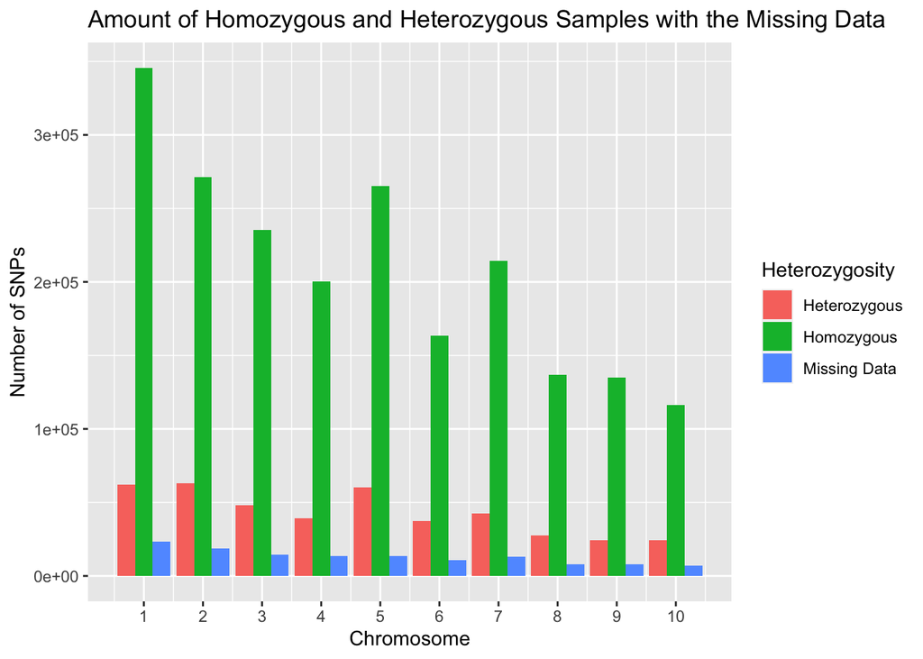

```r
ggplot(merged_fang_et_al_pivot_numeric) + geom_bar(mapping=aes(x = as.numeric(Chromosome), fill=Heterozygosity), position="dodge") + labs(x = "Chromosome", y="Number of SNPs") + ggtitle("Amount of Homozygous and Heterozygous Samples with the Missing Data") + scale_x_continuous(breaks=c(1,2,3,4,5,6,7,8,9,10))
```